# info550_project

Carol Liu

10/1/2020

```r
knitr::opts_chunk$set(echo = F)

#installed_pkgs <- row.names(installed.packages())

#pkgs <- c("ggplot2", "reshape2","kableExtra")
#for(p in pkgs){
#   if(!(p %in% installed_pkgs)){
#       install.packages(p)
#   }
#}

library(ggplot2)
library(reshape2)

contacts<-readRDS("usa_contacts")
georgiapop<-read.csv("georgiapop.csv")
parms <- read.csv("parms.csv")
int_scen <- read.csv("intervention_scenarios.csv")
```

# Background

As mentioned in the README.md, we use use a simple SEIR-like model I previously worked on to simulate cases of severe acute respiratory syndrome coronoavirus 2 (SARS-CoV2) in Georgia. State-level shelter-in-place orders began on March 16th where schools, work places and leisure areas were closed. At the time, I was subsequently interested in the impact of different social distancing strategies on infection transmission. The goal of my model was to address the following primary research question (from early May): how will the epidemic differ if current shelter-in-place orders are relaxed with a 50% return to work and no additional intervention versus a 100% return to work and either 1) additional measures to social distance at home; 2) isolation of 20% of pre-infectious cases identified from contact tracing or 3) isolation of 50% of pre-infectious cases identified from contact tracing?

The methods, model structure, input parameters and intervention scenarios are described in the README.md as well.

# Results

Below is a plot of new infections over time under the six intervention scenarios for all age groups.

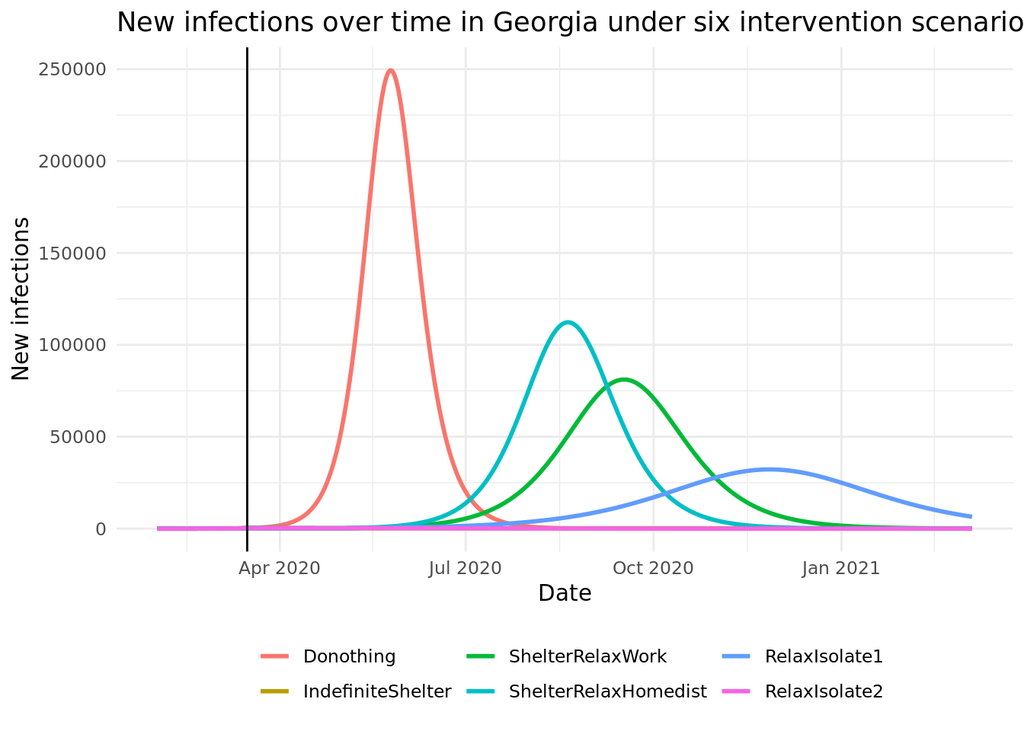

# SUmmary results

Below is some summary statistics under the six interventions. Specifically, we explore the peak date of incidence, number of new infections at peak incidence and the total infections from until the end of the simulation (spring 2021). We see that in a do nothing scenario, the cumulative cases is simulated to be 8.916377^{6}, in a scenario of indefinite shelter-in-place and perpetual maximum social distancing, the cumulative cases is simulated to be 5.5563^{4}. In reality, Georgia currently has over 300,000 cases. Alas, all models are wrong, some are useful.

```
##           Intervention   PeakDate PeakIncidence Totalnfections
## 1            DoNothing 2020-05-26        249384        8916377
## 2    IndefiniteShelter 2020-03-19           344          55563
## 3     ShelterRelaxWork 2020-09-18         81124        6339974
## 4 ShelterRelaxHomeDist 2020-08-21        112267        6794261
## 5        RelaxIsolate1 2020-11-28         32207        4157802
## 6        RelaxIsolate2 2020-03-19           344          37751
```